# Lecture 04 Exercise — Replicating a published beach-water classifier

PubH 6010 Independent Study · KNN, logistic regression & model evaluation

Your name: Katie O’Brien

2026-09-23

# 1 Why this matters for your project

Your project asks whether extreme-weather events change the risk of waterborne disease. Beaches are where that link is managed daily: rain and wave action move fecal bacteria into swimming water, and swimming in contaminated water raises the risk of gastrointestinal illness. Chicago samples its Lake Michigan beaches every morning, but a laboratory result that arrives after swimmers are in the water is too late, so managers need a **prediction** built from conditions known that morning.

In this exercise you **replicate a published model** on the authors’ own data, then evaluate it thoroughly. Replication is the fastest way to learn a method, and it puts you in a position to say something substantive about a paper rather than summarising it.

# 2 The paper and the data

> Elahi A, Shumway D, Kowalcyk M, Shrestha A, Caragea D, Caragea C, Dorevitch S. **Machine learning, generalization, and transfer learning for predicting the exceedance of fecal indicator bacteria thresholds at beaches.** *Environmental Science & Technology.* 2025;59(42):22386–22396. doi:10.1021/acs.est.5c02835 (open access)

Read the **Introduction** and **Materials and Methods**, especially “Train/Test Data Splitting”, “Data Imputation”, “Feature Scaling”, “Hyperparameter Fine-Tuning” and “Evaluating Methods Performance”, plus **Tables 1 and 4**.

`Data-CHI.csv` is the authors’ Chicago file, from the figshare archive cited in their Data and Code Sharing section. It holds daily enterococci (ENT) measured by qPCR at 19 Chicago beaches, with weather, wave, tide and solar variables linked by date. See `data_dictionary.Rmd`.

**Outcome:** exceedance of **320 CCE/100 mL**, the paper’s threshold — half the EPA Beach Action Value of 640 CCE, chosen to be more health-protective.

# 3 Your tasks

Use **tidyverse** (`readr`, `dplyr`, `tidyr`, `ggplot2`, `purrr`) plus `class` for KNN. Submit your knitted `.Rmd` and write-up answering the questions in **bold**.

## 3.1 Part A — Rebuild their analysis dataset

Follow the authors’ own preprocessing (their notebook is in `github.com/aliielahi/ONR-WQ`):

1. Keep years **2016–2019**.
2. Recompute `doy` (day of year) and `tide_gtm` (1 if `tide` is above its mean).
3. Define `exceed = ENT > 320`.
4. Use their **12 features**: `tide`, `tide_gtm`, `lograin3T`, `wet3`, `lograin7T`, `wet7`, `WVHT`, `Wtemp_B`, `rad`, `awind`, `owind`, `doy`. (These are what remains after they drop air temperature, dew point, wave period, turbidity and wind speed/direction — mostly variables that are unusable in Chicago or absent from their San Diego data.)
5. Split exactly as the paper does: **training = 2016–2018, test = 2019**. There is no validation set.
6. Report n and the percentage of negative samples for each split, and compare with **Table 1** of the paper.
7. Report the missingness of each feature in the training years, then follow their preprocessing: impute missing values with a draw from the feature’s **training** mean and SD (“noisy average”), then **min-max scale** using training minima and maxima.

```r
# set up
library(readr); library(dplyr); library(tidyr); library(ggplot2); library(purrr); library(class); library(lubridate)

# keeping years 2016 to 2019
chi <- read_csv("Data-CHI.csv", show_col_types = FALSE) |>
  filter(year >= 2016, year <= 2019) |>
  # recomputing day of year and tide
  mutate(doy      = as.integer(format(date, "%j")),
         tide_gtm = as.integer(tide > mean(tide, na.rm = TRUE)),
         # defining exceedance
         exceed   = as.integer(ENT > 320))

# using these 12 features
feats <- c("tide", "tide_gtm", "lograin3T", "wet3", "lograin7T", "wet7",
           "WVHT", "Wtemp_B", "rad", "awind", "owind", "doy")

# splits data into train (2016-2018) and test (2019)
train <- filter(chi, year <= 2018)
test  <- filter(chi, year == 2019)

# number of negative samples in train data
100-((sum(train$exceed)/4404)*100)
```

```
## [1] 68.1426
```

```r
# number of negative samples in test data
100-((sum(test$exceed)/1900)*100)
```

```
## [1] 79.15789
```

```r
# exceedance rate by year
train %>%
  group_by(year = year(date)) %>%
  summarize(total = n(),
            exceedance = sum(exceed),
            exceedance_rate = (exceedance/total)*100)
```

```
## # A tibble: 3 × 4
##    year total exceedance exceedance_rate
##   <dbl> <int>      <int>           <dbl>
## 1  2016   624         97            15.5
## 2  2017  1914        551            28.8
## 3  2018  1866        755            40.5
```

```r
test %>%
  summarize(year = 2019,
            total = n(),
            exceedance = sum(exceed),
            exceedance_rate = (exceedance/total)*100)
```

```
## # A tibble: 1 × 4
##    year total exceedance exceedance_rate
##   <dbl> <int>      <int>           <dbl>
## 1  2019  1900        396            20.8
```

```r
# Missingness in the training years
train |> select(all_of(feats)) |>
  summarise(across(everything(), ~ mean(is.na(.x)))) |>
  pivot_longer(everything(), names_to = "feature", values_to = "prop_missing") |>
  arrange(desc(prop_missing))
```

```
## # A tibble: 12 × 2
##    feature   prop_missing
##    <chr>            <dbl>
##  1 WVHT            0.588
##  2 lograin7T       0.424
##  3 wet7            0.424
##  4 lograin3T       0.216
##  5 wet3            0.216
##  6 Wtemp_B         0.188
##  7 rad             0.0159
##  8 awind           0.0154
##  9 owind           0.0154
## 10 tide            0
## 11 tide_gtm        0
## 12 doy             0
```

```r
# Their preprocessing: noisy-average imputation, then min-max scaling, TRAINING stats only
set.seed(2026)
# calculates mean, sd, max, and min for all features
stats <- train |> select(all_of(feats)) |>
  summarise(across(everything(), list(m = ~mean(.x, na.rm = TRUE), s = ~sd(.x, na.rm = TRUE),
                                      lo = ~min(.x, na.rm = TRUE), hi = ~max(.x, na.rm = TRUE))))
# imputing missing data
impute_scale <- function(df) {
  out <- df |> select(all_of(feats))
  for (v in feats) {
    x <- out[[v]]; na <- is.na(x)
    if (any(na)) x[na] <- rnorm(sum(na), stats[[paste0(v, "_m")]], stats[[paste0(v, "_s")]])
    out[[v]] <- (x - stats[[paste0(v, "_lo")]]) /
                (stats[[paste0(v, "_hi")]] - stats[[paste0(v, "_lo")]])
  }
  as.data.frame(out)
}

# imputed data
X_train <- impute_scale(train); X_test <- impute_scale(test)
# needed to change X_test <- impute_scale(train) to X_test <- impute_scale(test)
y_train <- train$exceed;        y_test <- test$exceed
```

> **Q1.** Do your numbers match Table 1? Why does the paper split by year instead of at random, and how does it tune hyperparameters with no validation set? Look at the exceedance rate by year — what does that variation imply for a model trained on 2016–18 and used in 2019?

## 3.2 Part B — KNN, tuned their way

8. Choose K by **4-fold cross-validation inside the training years** (the paper’s approach), scoring by AUC. Try K = 1, 5, 15, 25, 50, 100, 200, and report cross-validated AUC and sensitivity for each.

```r
# metrics used in the paper
metrics <- function(y, yhat) {
  tp <- sum(yhat == 1 & y == 1); fn <- sum(yhat == 0 & y == 1)
  fp <- sum(yhat == 1 & y == 0); tn <- sum(yhat == 0 & y == 0)
  sens <- tp / (tp + fn); spec <- tn / (tn + fp)
  ppv  <- ifelse(tp + fp > 0, tp / (tp + fp), NA); npv <- ifelse(tn + fn > 0, tn / (tn + fn), NA)
  pf1  <- 2 * ppv * sens / (ppv + sens); nf1 <- 2 * npv * spec / (npv + spec)
  w    <- c(sum(y == 1), sum(y == 0)) / length(y)
  round(c(sens = sens, spec = spec, PPV = ppv, NPV = npv, WF1 = w[1] * pf1 + w[2] * nf1), 3)
}
auc <- function(p, y) { r <- rank(p); n1 <- sum(y); n0 <- sum(1 - y)
  (sum(r[y == 1]) - n1 * (n1 + 1) / 2) / (n1 * n0) }

# function for KNN
knn_p1 <- function(Xfit, yfit, Xnew, k) {
  set.seed(2026)
  # KNN calculation
  f <- knn(Xfit, Xnew, cl = factor(yfit, levels = 0:1), k = k, prob = TRUE)
  # classification
  ifelse(f == "1", attr(f, "prob"), 1 - attr(f, "prob"))
}

# 4-fold CV inside the training years
set.seed(2026)
fold <- sample(rep(1:4, length.out = nrow(X_train)))
# for each K: for each fold f, fit on fold != f, score on fold == f, average the AUCs

# k values
k_values <- c(1, 5, 15, 25, 50, 100, 200)

# outer loop over K values, inner evaluation over 4 folds
cv_results <- do.call(rbind, lapply(k_values, function(k_curr) {

  # folding
  fold_metrics <- sapply(1:4, function(f) {
    # training data
    X_fit <- X_train[fold != f, , drop = FALSE]
    y_fit <- y_train[fold != f]

    X_val <- X_train[fold == f, , drop = FALSE]
    y_val <- y_train[fold == f]

    # KNN calculations
    p1_hat <- knn_p1(Xfit = X_fit, yfit = y_fit, Xnew = X_val, k = k_curr)
    y_hat  <- ifelse(p1_hat >= 0.5, 1, 0)

    # calculating AUC
    auc_score <- auc(p = p1_hat, y = y_val)
    m_scores  <- metrics(y = y_val, yhat = y_hat)

    c(AUC = auc_score, m_scores)
  })

  # averaging the scores across the folds
  mean_scores <- rowMeans(fold_metrics, na.rm = TRUE)

  # metrics
  data.frame(
    K    = k_curr,
    AUC  = round(mean_scores["AUC"], 3),
    sens = round(mean_scores["sens"], 3),
    spec = round(mean_scores["spec"], 3),
    PPV  = round(mean_scores["PPV"], 3),
    NPV  = round(mean_scores["NPV"], 3),
    WF1  = round(mean_scores["WF1"], 3)
  )
}))

print(cv_results)
```

```
##        K   AUC  sens  spec   PPV   NPV   WF1
## AUC    1 0.599 0.455 0.742 0.452 0.744 0.651
## AUC1   5 0.666 0.400 0.830 0.525 0.748 0.681
## AUC2  15 0.675 0.306 0.883 0.550 0.731 0.671
## AUC3  25 0.658 0.236 0.911 0.553 0.718 0.653
## AUC4  50 0.635 0.176 0.926 0.524 0.706 0.630
## AUC5 100 0.632 0.158 0.940 0.550 0.705 0.627
## AUC6 200 0.627 0.066 0.978 0.579 0.691 0.589
```

> **Q2.** How do AUC and sensitivity behave as K grows, and why do they behave differently? Relate this to the bias–variance trade-off (slide 12) and to class imbalance (slide 37).

Generally, as K grows, AUC increases and then decreases, peaking at K = 15 with AUC = 0.68. Sensitivity decreases as K increases. They behave differently because AUC is related to prediction across every cutoff while sensitivity evaluates one decision threshold at a time. How AUC and sensitivity behave is also related to the bias-variance trade-off, which is that when K increases, variance decreases but there is high bias. Additionally, when class imbalance is present, increasing K causes the majority observations (in this case, negative samples), to dominate, which leads to error rate being a poor summary measure.

## 3.3 Part C — Logistic regression

9. Fit a logistic regression on the training years with the same 12 features and report odds ratios with 95% CIs, sorted by p-value.

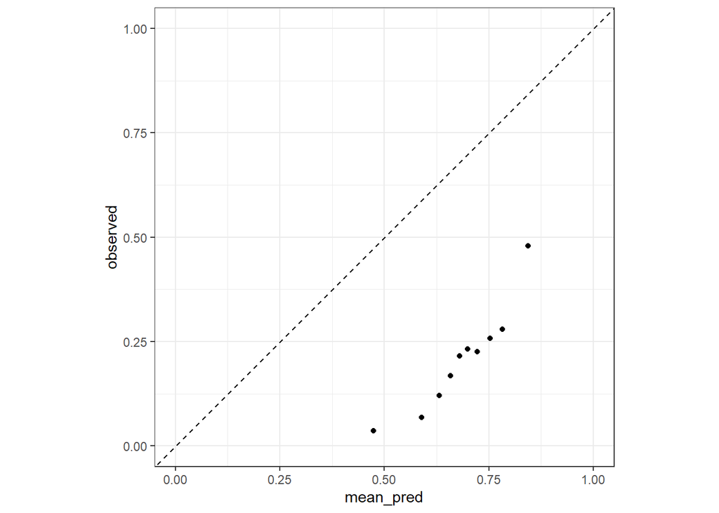

```r
# logistic regression model
fit <- glm(exceed ~ ., family = binomial(), data = bind_cols(X_train, exceed = y_train))
p_logit <- predict(fit, newdata = X_test, type = "response")

# calibration
tibble(p = p_logit, y = y_test) |> mutate(bin = ntile(p, 10)) |> group_by(bin) |>
  summarise(mean_pred = mean(p), observed = mean(y)) |>
  ggplot(aes(mean_pred, observed)) + geom_abline(linetype = 2) + geom_point() +
  coord_equal(xlim = c(0, 1), ylim = c(0, 1)) + theme_bw()
```

```r
# odds Ratios and 95% CIs, sorted by p-value
library(broom)
lr_results <- tidy(fit, conf.int = TRUE) |>
  filter(term != "(Intercept)") |>
  select(term, OR = estimate, CI_lower = conf.low, CI_upper = conf.high, p_value = p.value) |>
  mutate(sig = ifelse(p_value < 0.05, "*", "")) |>
  arrange(p_value)
print(lr_results)
```

```
## # A tibble: 12 × 6
##    term             OR CI_lower CI_upper  p_value sig
##    <chr>         <dbl>    <dbl>    <dbl>    <dbl> <chr>
##  1 tide       2.09       1.60     2.59   1.69e-16 "*"
##  2 awind     -2.37      -3.03    -1.71   1.70e-12 "*"
##  3 owind      1.16       0.564    1.75   1.37e- 4 "*"
##  4 doy        0.451      0.159    0.745  2.56e- 3 "*"
##  5 wet3       0.165     -0.0126   0.343  6.91e- 2 ""
##  6 WVHT       0.313     -0.0309   0.657  7.43e- 2 ""
##  7 lograin3T  0.143     -0.0981   0.385  2.45e- 1 ""
##  8 wet7      -0.115     -0.314    0.0848 2.59e- 1 ""
##  9 tide_gtm   0.123     -0.152    0.398  3.79e- 1 ""
## 10 lograin7T  0.0833    -0.220    0.388  5.91e- 1 ""
## 11 rad        0.0705    -0.211    0.353  6.24e- 1 ""
## 12 Wtemp_B   -0.000248  -0.345    0.343  9.99e- 1 ""
```

> **Q3.** Which features carry signal? Is rainfall among them, and does that match your expectation? The paper reports that wind and tide dominate its Chicago feature importance — do you see the same? (Because the features are min-max scaled, each OR compares the top of the training range with the bottom, so they are comparable across features.)

Significant predictors are tide, alongshore wind speed, offshore wind speed, and day of year. This is similar to what the paper finds. Rainfall is not among the significant predictors, which is not what I would have expected. This aligns with the papers findings that wind and tide dominate feature importance.

## 3.4 Part D — Evaluate on 2019

10. Predict for 2019 with both models. Report **sensitivity, specificity, PPV, NPV, weighted F1 and AUC** — the paper’s metrics. Put their Chicago-to-Chicago logistic and random-forest rows from **Table 4** in the same table for comparison.
11. Compare the **mean predicted probability** with the observed exceedance rate, and plot a **calibration curve** using decile bins.

```r
# predicting with KNN using k = 15 (highest AUC)
predict_knn <- knn_p1(Xfit = X_train, yfit = y_train, Xnew = X_test, k = 15)

# predicting with logistic regression
fit <- glm(exceed ~ ., family = binomial(), data = bind_cols(X_train, exceed = y_train))
p_logit <- predict(fit, newdata = X_test, type = "response")

# classifications at 0.5 threshold
yhat_logit <- ifelse(p_logit >= 0.5, 1, 0)
yhat_knn   <- ifelse(predict_knn >= 0.5, 1, 0)

# metrics
m_logit <- c(metrics(y = y_test, yhat = yhat_logit), AUC = round(auc(p = p_logit, y = y_test), 3))
m_knn   <- c(metrics(y = y_test, yhat = yhat_knn),   AUC = round(auc(p = predict_knn, y = y_test), 3))

# table 4 comparison
table4_comparison <- tibble(
  Model = c(
    "KNN",
    "Logistic Regression",
    "Paper Logistic Regression",
    "Paper Random Forest"
  ),
  Sensitivity = c(m_knn["sens"], m_logit["sens"], 0.220, 0.256),
  Specificity = c(m_knn["spec"], m_logit["spec"], 0.966, 0.856),
  PPV         = c(m_knn["PPV"],  m_logit["PPV"],  0.990, 0.710),
  NPV         = c(m_knn["NPV"],  m_logit["NPV"],  0.072, 0.454),
  `Weighted F1` = c(m_knn["WF1"],m_logit["WF1"],  0.535, 0.482),
  AUC         = c(m_knn["AUC"],  m_logit["AUC"],  0.693, 0.607)
)
print(table4_comparison)
```

```
## # A tibble: 4 × 7
##   Model                  Sensitivity Specificity   PPV   NPV `Weighted F1`   AUC
##   <chr>                        <dbl>       <dbl> <dbl> <dbl>         <dbl> <dbl>
## 1 KNN                          0.578       0.477 0.225 0.811         0.543 0.564
## 2 Logistic Regression          0.992       0.057 0.217 0.966         0.16  0.695
## 3 Paper Logistic Regres…       0.22        0.966 0.99  0.072         0.535 0.693
## 4 Paper Random Forest          0.256       0.856 0.71  0.454         0.482 0.607
```

```r
# observed exceedance rate
mean(y_test)
```

```
## [1] 0.2084211
```

```r
# mean predicted probability using logistic regression
mean(p_logit)
```

```
## [1] 0.6834817
```

```r
# mean predicted probability using KNN
mean(predict_knn)
```

```
## [1] 0.5426266
```

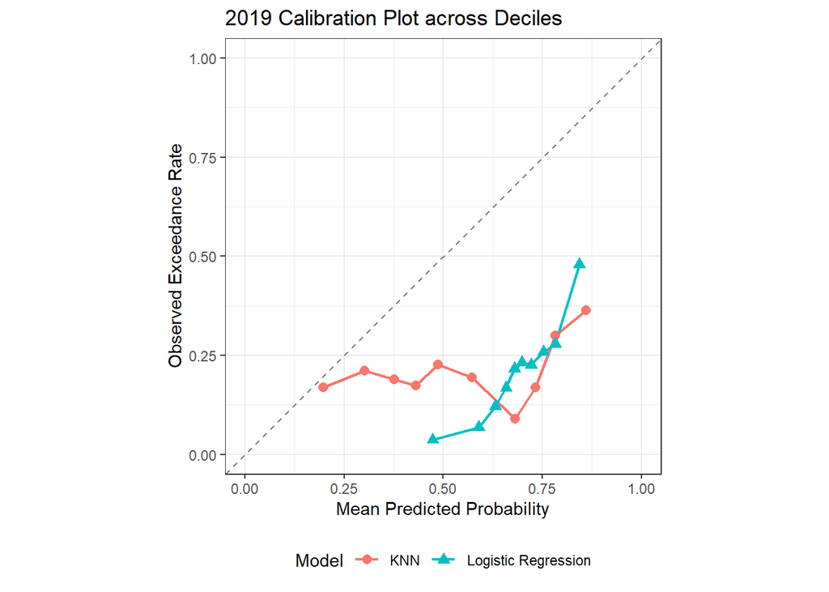

```r
# decile calibration plot
cal_data <- tibble(
  y = rep(y_test, 2),
  p = c(p_logit, predict_knn),
  Model = factor(rep(c("Logistic Regression", paste0("KNN")), each = length(y_test)))
) |>
  group_by(Model) |>
  mutate(bin = ntile(p, 10)) |>
  group_by(Model, bin) |>
  summarise(
    mean_pred = mean(p),
    observed  = mean(y),
    .groups   = "drop"
  )

ggplot(cal_data, aes(x = mean_pred, y = observed, color = Model, shape = Model)) +
  geom_abline(intercept = 0, slope = 1, linetype = "dashed", color = "grey50") +
  geom_line(linewidth = 0.8) +
  geom_point(size = 2.5) +
  coord_equal(xlim = c(0, 1), ylim = c(0, 1)) +
  labs(
    title = "2019 Calibration Plot across Deciles",
    x = "Mean Predicted Probability",
    y = "Observed Exceedance Rate",
    color = "Model",
    shape = "Model"
  ) +
  theme_bw() +
  theme(legend.position = "bottom")
```

> **Q4.** How close is your AUC to theirs? Now compare operating points: at a 0.5 cutoff, how many days does your model flag, and how many does theirs? What does it mean that two models can share an AUC and behave so differently?

> **Q5.** What does the calibration plot show that AUC cannot? Why does the paper never report it?

The calibration plot shows accuracy, in this case that the mean predicted probability has a much wider range with the KNN model compared to the logistic regression model. In contrast, the KNN model has a smaller range for observed expected rate compared to the logistic regression model. The paper does not report this because accuracy is not one of the standard metrics used.

12. **Diagnose the over-prediction.** Compare the range of `tide` in the training years with its range in 2019 — and look at the *scaled* test values, remembering that min-max scaling puts training data in [0, 1]. Then refit without `tide` and `tide_gtm` and compare AUC, mean predicted probability, sensitivity and specificity.

```r
# comparing ranges
max(train$tide) - min(train$tide)
```

```
## [1] 0.554736
```

```r
# range of tide in training years: 0.55
max(test$tide) - min(test$tide)
```

```
## [1] 0.481584
```

```r
# range of tide in test years: 0.48

max(X_train$tide) - min(X_train$tide)
```

```
## [1] 1
```

```r
# range of tide in the scaled training years: 1
max(X_test$tide) - min(X_test$tide)
```

```
## [1] 0.8681319
```

```r
# range of tide in the scaled test years: 0.86


# refitting without tide and tide_gtm
X_train_no_tide <- X_train %>% select(-tide, -tide_gtm)
X_test_no_tide <- X_test %>% select(-tide, -tide_gtm)

# logistic regression
fit_no_tide <- glm(exceed ~ ., family = binomial(), data = bind_cols(X_train_no_tide, exceed = y_train))
p_logit_no_tide <- predict(fit_no_tide, newdata = X_test_no_tide, type = "response")

# KNN
predict_knn_no_tide <- knn_p1(Xfit = X_train_no_tide, yfit = y_train, Xnew = X_test_no_tide, k = 15)

# classifications at 0.5 threshold
yhat_logit_no_tide <- ifelse(p_logit_no_tide >= 0.5, 1, 0)
yhat_knn_no_tide   <- ifelse(predict_knn_no_tide >= 0.5, 1, 0)

# compute test metrics using existing
m_logit_no_tide <- c(metrics(y = y_test, yhat = yhat_logit_no_tide), AUC = round(auc(p = p_logit_no_tide, y = y_test), 3))
m_knn_no_tide   <- c(metrics(y = y_test, yhat = yhat_knn_no_tide),   AUC = round(auc(p = predict_knn_no_tide, y = y_test), 3))

# table 4 comparison
new_models <- tibble(
  Model = c(
    "KNN",
    "Logistic Regression"
  ),
  Sensitivity = c(m_knn_no_tide["sens"], m_logit_no_tide["sens"]),
  Specificity = c(m_knn_no_tide["spec"], m_logit_no_tide["spec"]),
  AUC         = c(m_knn_no_tide["AUC"],  m_logit_no_tide["AUC"]),
  `Mean predicted probability` = c(
    mean(predict_knn_no_tide),
    mean(p_logit_no_tide)
))

print(new_models)
```

```
## # A tibble: 2 × 5
##   Model               Sensitivity Specificity   AUC `Mean predicted probability`
##   <chr>                     <dbl>       <dbl> <dbl>                        <dbl>
## 1 KNN                       0.295       0.829 0.566                        0.329
## 2 Logistic Regression       0.109       0.955 0.632                        0.333
```

When removing tide and tide_gtm from the KNN model, sensitivity decreases, specificity increases, AUC stays about the same, and mean predicted probability decreases. For the logistic regression model, sensitivity decreases, specificity increases, AUC decreases slightly, and mean predicted probability decreases.

> **Q6.** What is wrong with lake level as a predictor here? (Look up Lake Michigan levels in 2019.) What happens to AUC when you drop it, and what happens to the probabilities? If AUC alone selects models, which model wins — and is that the one you would deploy?

The issue with lake level as a predictor is that certain years can be unusually high, leading to annual inconsistency. In 2019, Lake Michigan had unusually high water levels. When lake level (tide and tide_gtm) are dropped from the model, AUC decreases, and the predicted probability also decreases. The predicted probabilities become closer to the observed exceedance rate. In this case, tide may be an extrapolating predictor, and the model may be better without it.

## 3.5 Part E — Thresholds

13. Using the model **without** the lake-level terms, compare thresholds: 0.5, the training prevalence, and the value that gives 85% specificity.

```r
# classifications at 0.5 threshold
yhat_logit_no_tide <- ifelse(p_logit_no_tide >= 0.5, 1, 0)
yhat_knn_no_tide   <- ifelse(predict_knn_no_tide >= 0.5, 1, 0)
# test metrics
m_logit_no_tide <- c(metrics(y = y_test, yhat = yhat_logit_no_tide), AUC = round(auc(p = p_logit_no_tide, y = y_test), 3))
m_knn_no_tide   <- c(metrics(y = y_test, yhat = yhat_knn_no_tide),   AUC = round(auc(p = predict_knn_no_tide, y = y_test), 3))

# classifications at training prevalence threshold (0.269)
yhat_logit_no_tide_tp <- ifelse(p_logit_no_tide >= 0.269, 1, 0)
yhat_knn_no_tide_tp   <- ifelse(predict_knn_no_tide >= 0.269, 1, 0)
# test metrics
m_logit_no_tide_tp <- c(metrics(y = y_test, yhat = yhat_logit_no_tide_tp), AUC = round(auc(p = p_logit_no_tide, y = y_test), 3))
m_knn_no_tide_tp   <- c(metrics(y = y_test, yhat = yhat_knn_no_tide_tp),   AUC = round(auc(p = predict_knn_no_tide, y = y_test), 3))

# classifications at value that gives 85% specificity
yhat_logit_no_tide_sen <- ifelse(p_logit_no_tide >= 0.54, 1, 0)
yhat_knn_no_tide_sen   <- ifelse(predict_knn_no_tide >= 0.54, 1, 0)
# test metrics
m_logit_no_tide_sen <- c(metrics(y = y_test, yhat = yhat_logit_no_tide_sen), AUC = round(auc(p = p_logit_no_tide, y = y_test), 3))
m_knn_no_tide_sen   <- c(metrics(y = y_test, yhat = yhat_knn_no_tide_sen),   AUC = round(auc(p = predict_knn_no_tide, y = y_test), 3))

# table 4 comparison
threshold_comparison <- tibble(
  Model = c(
    "KNN - 0.5 Threshold",
    "Logistic Regression - 0.5 Threshold",
    "KNN - Training Prevalence Threshold",
    "Logistic Regression - Training Prevalence Threshold",
    "KNN - 85% Sensitivity Threshold",
    "Logistic Regression - 85% Sensitivity Threshold"
  ),
  Sensitivity = c(m_knn_no_tide["sens"], m_logit_no_tide["sens"], m_knn_no_tide_tp["sens"],
                  m_logit_no_tide_tp["sens"], m_knn_no_tide_sen["sens"], m_logit_no_tide_sen["sens"]),
  Specificity = c(m_knn_no_tide["spec"], m_logit_no_tide["spec"], m_knn_no_tide_tp["spec"],
                  m_logit_no_tide_tp["spec"], m_knn_no_tide_sen["spec"], m_logit_no_tide_sen["spec"]),
  AUC         = c(m_knn_no_tide["AUC"],  m_logit_no_tide["AUC"], m_knn_no_tide_tp["AUC"],
                  m_logit_no_tide_tp["AUC"], m_knn_no_tide_sen["AUC"], m_logit_no_tide_sen["AUC"]),
  `Mean predicted probability` = c(
    mean(predict_knn_no_tide),
    mean(p_logit_no_tide),
    mean(predict_knn_no_tide),
    mean(p_logit_no_tide),
    mean(predict_knn_no_tide),
    mean(p_logit_no_tide)
))

print(threshold_comparison)
```

```
## # A tibble: 6 × 5
##   Model                     Sensitivity Specificity   AUC Mean predicted proba…¹
##   <chr>                           <dbl>       <dbl> <dbl>                  <dbl>
## 1 KNN - 0.5 Threshold             0.295       0.829 0.566                  0.329
## 2 Logistic Regression - 0.…       0.109       0.955 0.632                  0.333
## 3 KNN - Training Prevalenc…       0.571       0.495 0.566                  0.329
## 4 Logistic Regression - Tr…       0.886       0.266 0.632                  0.333
## 5 KNN - 85% Sensitivity Th…       0.197       0.888 0.566                  0.329
## 6 Logistic Regression - 85…       0.056       0.973 0.632                  0.333
## # ℹ abbreviated name: ¹`Mean predicted probability`
```

> **Q7.** The USGS target quoted in the paper is sensitivity 0.50 with specificity 0.85. Do you reach it? Do any of the models in their Table 4? Which threshold would you recommend to the Chicago Park District, and what value judgment does that rest on? One catch: with no validation set, you had to read that threshold off the test year — the same thing slide 41 does. Why is that optimistic, and what would you do instead?

## 3.6 Part F — Read against the paper

> **Q8.** Write a short critique (half a page). Useful angles: their feature set was fixed by what Chicago and San Diego have in common rather than by what predicts enterococci in Chicago; wave height is more than half missing in the training years and is imputed from its own mean and SD; `tide_gtm` is defined using the mean of the whole series, including the test year; and their Table 4 reports PPV 0.990 alongside sensitivity 0.220 for the Chicago logistic model, which is hard to reconcile with 20.8% prevalence. Also: can any of this establish that rainfall *causes* exceedances? What design would?

The two model approaches reach similar conclusions, and generally have high specificity and low sensitivity. It is unclear why the sensitivity remains low in many of the models, both the ones created here and the ones in the paper, since the observed exceedance rate is not that low at 21%. Additionally, the approach of using san diego to predict chicao and give versa is interesting, given that these two environments vary dramatically, and important predictors in one location may not be important in the other location.

*Optional:* fit a three-class model (below half-BAV, half-BAV to BAV, above BAV) with `nnet::multinom()` and see which classes it ever predicts (slides 24–31).